# Dynamic ATAC-peaks in KRasG12D colonic epithelium using merged peaks with Csnk2a1 subset

Bing Shui

2021-11-23

# Library loading and set up

```r
library(tidyverse)
library(DESeq2)
library(knitr)
library(kableExtra)
library(plyranges)
library(stringr)
library(biobroom)
library(ggrepel)
library(RColorBrewer)
library(gplots)
library(biomaRt)
library(ChIPseeker)
library(TxDb.Mmusculus.UCSC.mm10.knownGene)
library(mixOmics)
library(mosaic)
library(clusterProfiler)
library(DOSE)
library(org.Mm.eg.db)
library(pathview)
library(AnnotationDbi)
library(fgsea)
library(rvest)
library(ggseqlogo)
library(gridExtra)
library(rtracklayer)
library(Biostrings)
library(Rsamtools)
library(data.table)
library(grid)
library(apeglm)
```

# Load dataset

This dataset is generated using WT and KRas-G12D expressingn colonic epithelium from mouse. Mice user are - Fabp-Cre/+ - Fabp-Cre/+; KRasG12D/+

Alignment and peak calling was done using the `bcbio` ATAC-Seq pipeline following instructions described here: (https://bcbio-nextgen.readthedocs.io/en/latest/contents/atac.html)

Merged peak data are used here. This is obtained by combining all peaks from all samples, merging peaks within 500bp of each other, and using `featureCount` to count all reads in the peaks.

```r
metadata = readr::read_csv("Data/bcbio_output/metadata.csv") %>%
  dplyr::rename("sample"=...1) %>%
  dplyr::select(-batch, -phenotype) %>%
  dplyr::filter(tissue == "colon_epithelium") %>%
  dplyr::filter(sample != "Kras_colon_rep3") %>%
  mutate(condition=relevel(factor(condition), ref="WT")) %>%
  as.data.frame()
rownames(metadata) = metadata$sample
counts_all = readr::read_tsv("Data/bcbio_output/merged/merged-counts_csnk2a1.tsv") %>%
  tibble::column_to_rownames("id")
```

Metadata

```r
metadata %>%
  kable() %>%
  kable_styling()
```

|  | sample | condition | replicate | tissue |
| --- | --- | --- | --- | --- |
| WT_colon_rep1 | WT_colon_rep1 | WT | rep1 | colon_epithelium |
| WT_colon_rep2 | WT_colon_rep2 | WT | rep2 | colon_epithelium |
| WT_colon_rep3 | WT_colon_rep3 | WT | rep3 | colon_epithelium |
| Kras_colon_rep1 | Kras_colon_rep1 | Kras | rep1 | colon_epithelium |
| Kras_colon_rep2 | Kras_colon_rep2 | Kras | rep2 | colon_epithelium |

Load Ensembl ID dataset

```r
ensembl = useMart("ensembl", dataset="mmusculus_gene_ensembl")
symbols = getBM(attributes=c("entrezgene_id", "mgi_symbol", "ensembl_gene_id"), mart=ensembl) %>%
  dplyr::rename("geneId"=entrezgene_id) %>%
  mutate(geneId=as.character(geneId))

save(symbols, file = "Data/symbols.rda")
```

# Cleanup

We need to do a little it of cleanup before contining. We need to remove peaks that appear in regions known to be false positive machines, called the blacklist regions. We also are interested in regions that could be affecting expression via chromatin accessability, so we’ll only consider peaks within a window around the transcription start sites of genes.

## Blacklist region removal

Turn out the peak at the TSS of Csnk2a1 falls into the blacklist because that region is considered high signal. I need to manually add it back after blacklist filtering.

```r
load("Data/symbols.rda")

expand_region_string = function(df, column) {
  df = as.data.frame(df)
  tokens = str_split_fixed(df[,column], ":", 2)
  chrom = tokens[,1]
  start = as.numeric(str_split_fixed(tokens[,2], "-", 2)[, 1])
  end = as.numeric(str_split_fixed(tokens[,2], "-", 2)[, 2])
  regions = data.frame(seqnames=chrom, start=start, end=end)
  df %>%
    bind_cols(regions)
}
blacklist = readr::read_tsv("Data/mm10-blacklist.v2.bed.gz", col_names=c("seqnames", "start", "end")) %>%
  as_granges()
blacklist_peaks = counts_all %>%
  tibble::rownames_to_column("peak") %>%
  expand_region_string("peak") %>%
  as_granges() %>%
  join_overlap_inner(blacklist) %>%
  tidy() %>%
  pull(peak)
counts = counts_all[!rownames(counts_all) %in% blacklist_peaks, ]
counts <- rbind(counts, counts_all[291429,])
counts <- counts[,-6]
```

A few peaks overlap the ENCODE blacklist regions, so we removed them from the analysis. There were 4897 that overlapped with the blacklist regions.

## Open region annotation

Here we annotate the peaks that we called with contextual genomic information. We can also see that some peaks are annotated in multiple regions, this can’t be helped as genes overlap so there are areas where multiple features of genes overlap.

```r
annotatedobj = ChIPseeker::annotatePeak(counts %>%
                                        tibble::rownames_to_column("peak") %>%
                                        expand_region_string("peak") %>%
                                        as_granges(), TxDb = TxDb.Mmusculus.UCSC.mm10.knownGene)
```

```
## >> preparing features information...      2021-11-23 09:07:06
## >> identifying nearest features...        2021-11-23 09:07:08
## >> calculating distance from peak to TSS...   2021-11-23 09:07:15
## >> assigning genomic annotation...        2021-11-23 09:07:15
## >> assigning chromosome lengths           2021-11-23 09:07:53
## >> done...                    2021-11-23 09:07:53
```

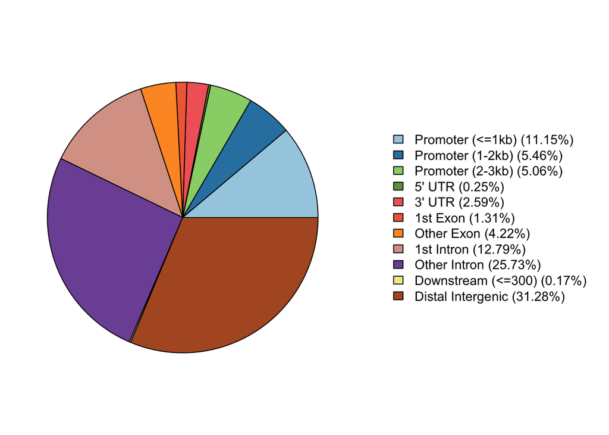

```r
plotAnnoPie(annotatedobj)
```

## Remove peaks not near TSS

Generally we only care about peaks that are close to gene, here we are pretty lenient and consider peaks that are within 1000 bases of a transcription start site of a gene.

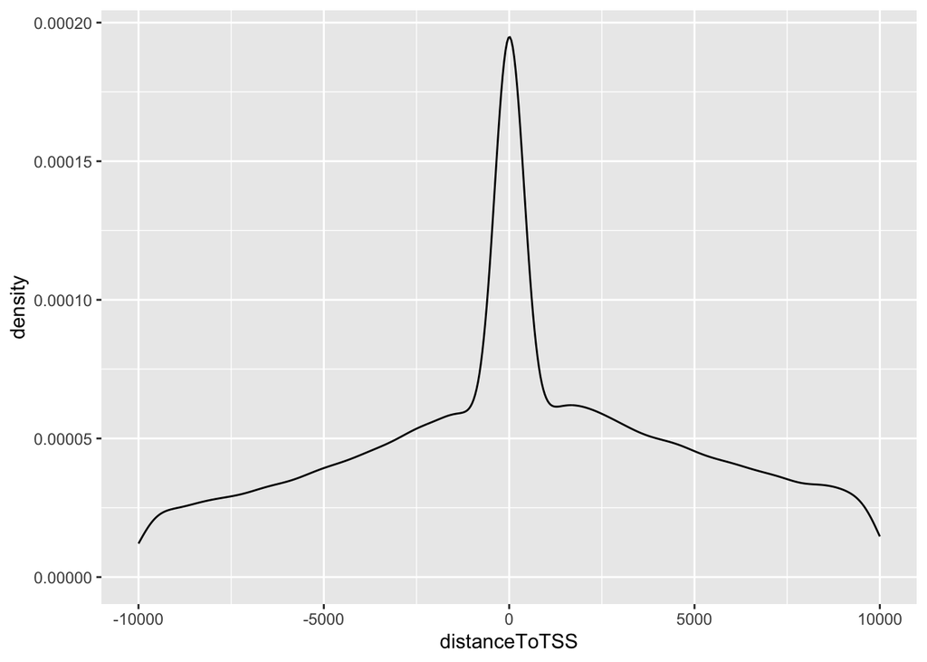

```r
annotated = annotatedobj %>%
  as.GRanges() %>%
  tidy()
ggplot(annotated, aes(distanceToTSS)) +
  stat_density(geom="line") +
  xlim(c(-10000,10000))
```

```r
KEEP_DISTANCE = 1000
close_to_tss = annotated %>%
  dplyr::filter(abs(distanceToTSS) < KEEP_DISTANCE) %>%
  pull(peak)
counts = counts[rownames(counts) %in% close_to_tss,]
```

Most peaks fall close to the TSS, but there are some that are very far away from the TSS. We’ll remove peaks that aren’t anywhere near the TSS for a gene from the analysis. We’ll keep only peaks within 1000 bases of a TSS. This leaves us with 31937 peaks to consider.

## Post filtering peak annotation

Here we annotate the peaks post-filtering

```r
annotatedobj = ChIPseeker::annotatePeak(counts %>%
                                        tibble::rownames_to_column("peak") %>%
                                        expand_region_string("peak") %>%
                                        as_granges(), TxDb = TxDb.Mmusculus.UCSC.mm10.knownGene)
```

```
## >> preparing features information...      2021-11-23 09:07:58
## >> identifying nearest features...        2021-11-23 09:07:58
## >> calculating distance from peak to TSS...   2021-11-23 09:07:59
## >> assigning genomic annotation...        2021-11-23 09:07:59
## >> assigning chromosome lengths           2021-11-23 09:08:03
## >> done...                    2021-11-23 09:08:03
```

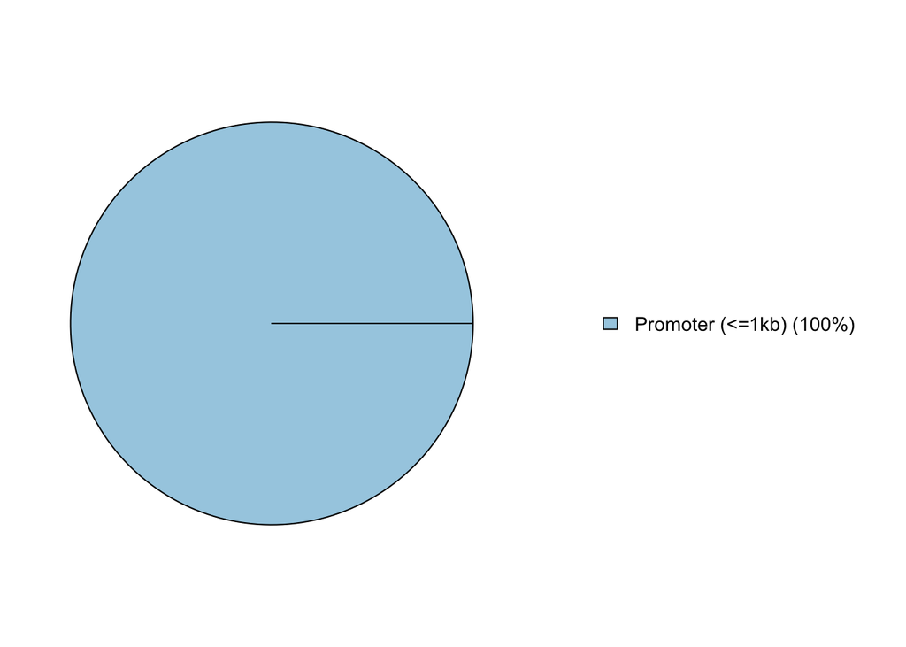

```r
plotAnnoPie(annotatedobj)
```

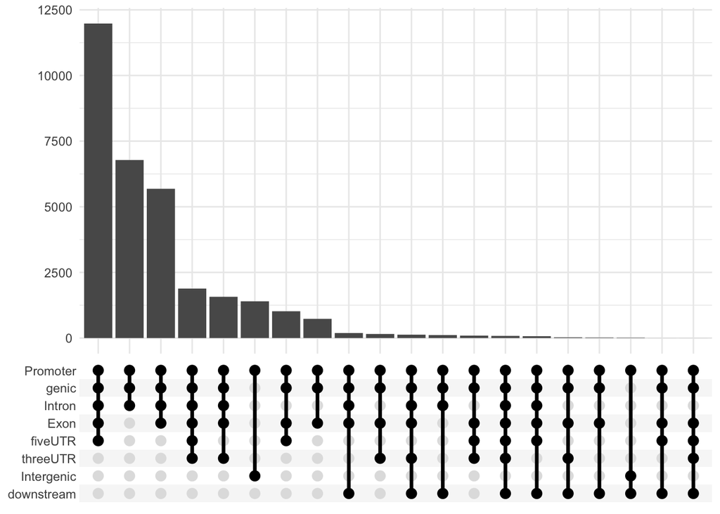

```r
upsetplot(annotatedobj)
```

# Differential affinity analysis

```r
dds = DESeqDataSetFromMatrix(counts, metadata, design=~condition)
dds = DESeq(dds)
# Print scale factors for BW normalization
1/sizeFactors(dds)
```

```
##   WT_colon_rep1   WT_colon_rep2   WT_colon_rep3 Kras_colon_rep1 Kras_colon_rep2
##       0.6848165       0.6743022       0.8273510       1.5667404       1.6676648
```

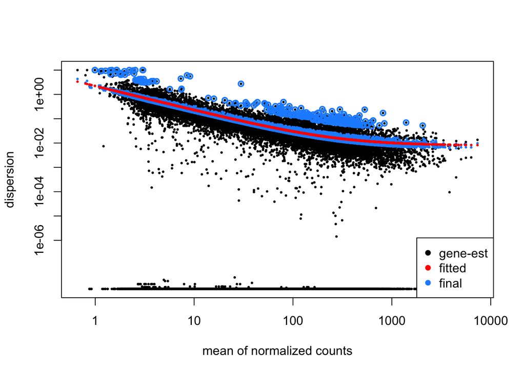

```r
plotDispEsts(dds)
```

```r
CUTOFF = 0.05
dds_result <- lfcShrink(dds, coef = "condition_Kras_vs_WT", type = "normal")
```

```
## using 'normal' for LFC shrinkage, the Normal prior from Love et al (2014).
##
## Note that type='apeglm' and type='ashr' have shown to have less bias than type='normal'.
## See ?lfcShrink for more details on shrinkage type, and the DESeq2 vignette.
## Reference: https://doi.org/10.1093/bioinformatics/bty895
```

## QC

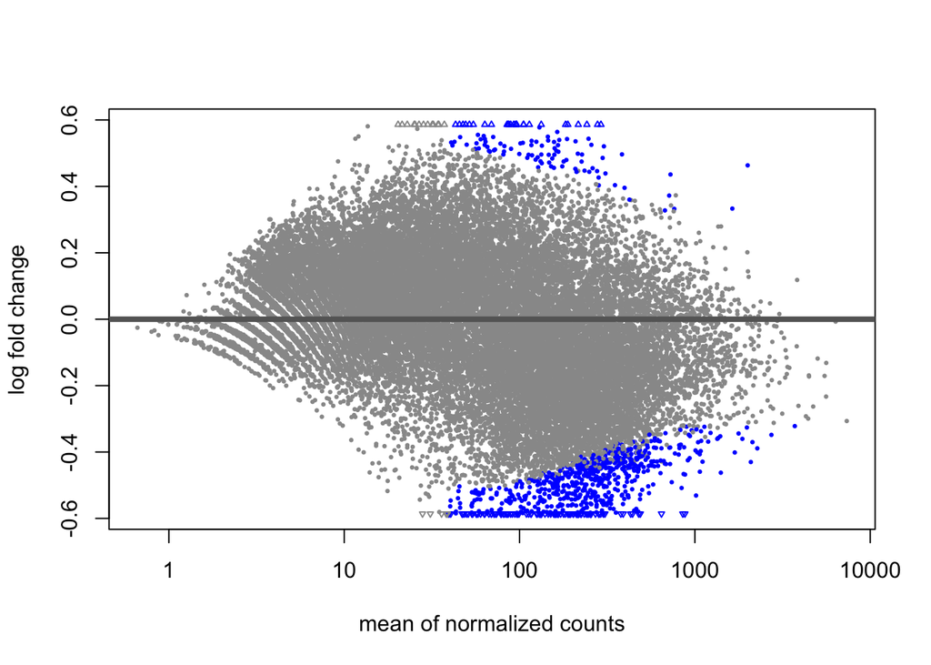

```r
DESeq2::plotMA(dds_result)
```

```r
dds_transform <- varianceStabilizingTransformation(dds)
rawCountTable_transform <- as.data.frame(assay(dds_transform))
pseudoCount_transform = log2(rawCountTable_transform + 1)
```

The top 500 most variable genes are selected for PCA analysis.

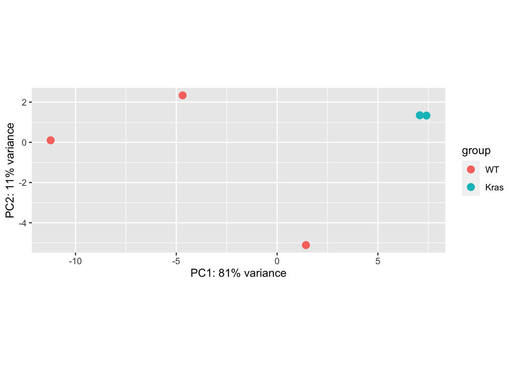

```r
plotPCA(dds_transform, intgroup = "condition", ntop = 500)
```

## Output results

Signal to noise ratio is calculated using the definition given by Broad [GSEA](https://www.gsea-msigdb.org/gsea/doc/GSEAUserGuideFrame.html?Run_GSEA_Page).

```r
markup_deseq2 = function(res) {
  resanno = res %>%
    expand_region_string("peak") %>%
    as_granges()
  ChIPseeker::annotatePeak(resanno, TxDb=TxDb.Mmusculus.UCSC.mm10.knownGene) %>%
    as.GRanges() %>%
    tidy() %>%
    left_join(symbols, by="geneId")
}

res = dds_result %>%
  as_tibble(rownames = "peak")

# calculate signal-to-noise ratio for GSEA later
s2n <- function(num_list, cond_1 = c(4:5), cond_2 = c(1:3)) {
  mean1 <- mean(num_list[cond_1])
  if (mean1 == 0) {
    mean1 = 1
  }
  mean2 <- mean(num_list[cond_2])
  if (mean2 == 0) {
    mean2 = 1
  }
  sd1 <- sd(num_list[cond_1])
  sd2 <- sd(num_list[cond_2])
  sd1 <- min(sd1, 0.2*abs(mean1))
  sd2 <- min(sd2, 0.2*abs(mean2))
  s2nvalue <- (mean1-mean2)/(sd1+sd2)
  return(s2nvalue)
}

rawCountTable <- as.data.frame(DESeq2::counts(dds, normalize = TRUE))

res$s2n <- apply(rawCountTable,1,s2n)

res <- markup_deseq2(res)
```

```
## >> preparing features information...      2021-11-23 09:08:50
## >> identifying nearest features...        2021-11-23 09:08:50
## >> calculating distance from peak to TSS...   2021-11-23 09:08:51
## >> assigning genomic annotation...        2021-11-23 09:08:51
## >> assigning chromosome lengths           2021-11-23 09:08:55
## >> done...                    2021-11-23 09:08:55
```

```r
res <- res[!duplicated(res$peak),]

write.csv(res, "Result/ATAC_ce_Kras-WT_merged_Csnk2a1subset.csv", row.names = FALSE)

rawCountTable <- rawCountTable %>% rownames_to_column(var = "peak")
rawCountTable <- left_join(rawCountTable, res[,c(6,24)], by = c("peak" ="peak"))

write.csv(rawCountTable, "Result/ATAC_ce_normalized_count_Csnk2a1 subset.csv", row.names = FALSE, na = "")
```

### Description of output files

- **start**: start of peak
- **end**: end of peak
- **width**: width of peak
- **strand**: strand of peak
- **seqname**: chromosome of peak
- **peak**: ID of peak
- **baseMean**: mean count of reads at peak for all samples
- **estimate**: log2 fold change of comparison
- **stderror**: standard error of the log2 fold change
- **statistic**: value of test statistic (Wald test)
- **p.value**: unadjusted p-value
- **p.adjusted**: adjusted p-value by BH correction
- **annotation**: proximity to nearest gene feature
- **geneChr**: chromosome of gene
- **geneStart**: start coordinate of gene
- **geneEnd**: end coordinate of gene
- **geneId**: Entrez gene ID of gene
- **transcriptId**: transcript ID
- **distanceToTSS**: distance to nearest transcription start site
- **mgi_symbol**: gene symbol from MGI